# Analyses: Classification with MLP

Chris Bentz

06.03.2025

# Description

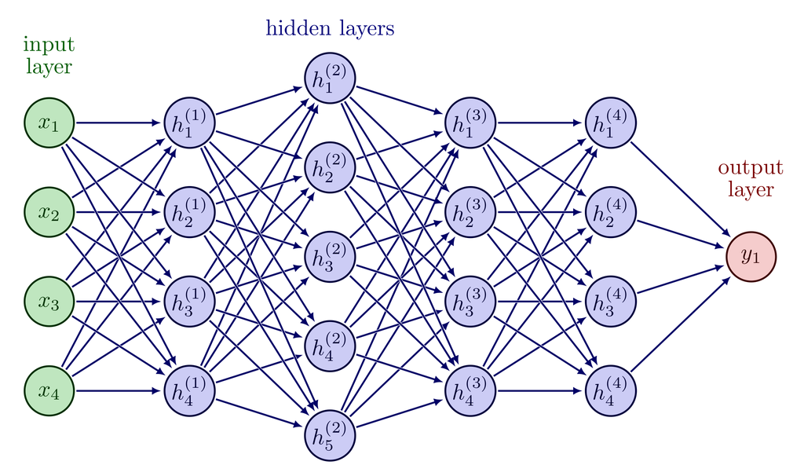

Example of one of the more complex architectures. This includes four hidden layers of four and five hidden units.

```r
knitr::include_graphics("~/Github/PaleoSigns/figures_external/mlpExample.png")
```

# Session Info

Give the session info (reduced).

```
## [1] "R version 4.3.3 (2024-02-29)"
```

```
## [1] "x86_64-pc-linux-gnu"
```

# Load Packages

If the libraries are not installed yet, you need to install them using, for example, the command: install.packages(“ggplot2”). For the Hrate package this is different, since it comes from github. The devtools library needs to be installed, and then the install_github() function is used.

```r
# install the latest version of neuralnet with bug fixes: devtools::install_github("bips-hb/neuralnet")
library(neuralnet)
library(sigmoid)
library(caret)
library(dplyr)
```

Give the package versions.

```
##     dplyr     caret   lattice   ggplot2   sigmoid neuralnet
##   "1.1.4"   "7.0-1"  "0.22-5"   "3.5.1"   "1.4.0"  "1.44.2"
```

# Load Data

Load data table with estimated feature values per sequence.

```r
# load feature value estimations
estimations.df <- read.csv("~/Github/PaleoSigns/results/features/features_combined.csv")
head(estimations.df)
```

```
##        id   subcorpus           sequence num.tokens num.types huni.chars
## 1 bst0001 Aurignacian vvvvvvvvvvvvvvvvvv         18         1  0.0000000
## 2 gkl0001 Aurignacian       ||| //////_V         12         5  1.8962406
## 3 gkl0002 Aurignacian              vvvvv          5         1  0.0000000
## 4 gkl0003 Aurignacian          vvvv vvvv          9         2  0.5032583
## 5 gkl0004 Aurignacian     vvvvvvvvvvvvvv         14         1  0.0000000
## 6 gkl0005 Aurignacian                |||          3         1  0.0000000
##   hrate.chars  ttr.chars  rm.chars
## 1   0.6171397 0.05555556 1.0000000
## 2   1.5295563 0.41666667 0.6363636
## 3   0.5711903 0.20000000 1.0000000
## 4   0.9060047 0.22222222 0.7500000
## 5   0.6379550 0.07142857 1.0000000
## 6   0.4308271 0.33333333 1.0000000
```

Choose subcorpora for binary classification.

```r
# choose subcorpora to compare: "Aurignacian", "TeDDi", "Cuneiform (Uruk V)",
# "Cuneiform (Uruk IV)", "Cuneiform (Uruk III)".
subcorpus1 <- "Aurignacian"
subcorpus2 <- "TeDDi"
selected <- c(subcorpus1, subcorpus2)
estimations.subset <- estimations.df[estimations.df$subcorpus %in% selected, ]

# downsample to have the same number of sequences across different combinations of corpora
# comment this out to use all the sequences (unbalanced across combinations of corpora)
# set.seed(02152018)
# estimations.subset <- sample_n(estimations.subset, 300)

# exclude sequences under a certain length
# estimations.subset <- estimations.subset[estimations.subset$num.tokens > 10, ]
```

Remove NAs (whole row)

```r
estimations.subset <- na.omit(estimations.subset)
```

# Center and scale the data

```r
# first four columns are meta information, the others are the feature values
# be aware that this needs to be changed in case of other table format
estimations.scaled <- cbind(estimations.subset[, c("id", "subcorpus", "sequence",
                                                   "num.tokens", "num.types")],
                            scale(estimations.subset[, c("huni.chars", "hrate.chars",
                                                         "ttr.chars", "rm.chars")]))
```

# Create Training and Test Sets

```r
# Generating seed
set.seed(09012020)
# Randomly generating our training and test samples with a respective ratio of 2/3 and 1/3
datasample <- sample(2, nrow(estimations.scaled), replace = TRUE, prob = c(0.67, 0.33))
# Generate training set (select rows randomly by using datasample vector)
train <- estimations.scaled[datasample == 1, 1:ncol(estimations.scaled)]
train.n <- nrow(train)
print(train.n)
```

```
## [1] 850
```

```r
# Generate test set
test <- estimations.scaled[datasample == 2, 1:ncol(estimations.scaled)]
# number of data points in test set
test.n <- nrow(test)
print(test.n)
```

```
## [1] 403
```

# Implement MLP classifier

This is partly based on code given at http://uc-r.github.io/ann_classification (last accessed 18.01.2023). The activation function (tanh), error function (SSE), and backpropagation algorithm (rprop+) are here chosen according to the best model performance for sequences of 100 characters reported in Bentz (2023).

```r
# Generate list of hidden unit architectures (number of layers and units)
# Choose number of random architectures
arch.no <- 100
# initialize empty list of hidden unit architectures
hidden.list <- vector(mode = "list", length = arch.no)
# set seed for reproducible results
set.seed(09012020)
# run loop to generate number of layers and hidden units randomly
for (i in 1:arch.no) {
  layer.no <- round(runif(1, min = 1, max = 4), 0)
  hidden.units <- round(runif(layer.no, min = 1, max = 5), 0)
  hidden.list[[i]] <- hidden.units
}
# remove duplicate hidden structures, i.e. only use "unique" vectors of numbers
hidden.list <- unique(hidden.list)

# Manual list of architectures for testing
# hidden.list <- list(c(4,4))

# initialize dataframe to append results to
results.df <- data.frame(hidden.structure = character(0),
                         hidden.size = numeric(0), hidden.depth = numeric(0),
                         err.fct = character(0), act.fct.name = character(0),
                         algorithm = character(0), baseline = numeric(0),
                         accuracy = numeric(0), accuracy.pvalue = numeric(0),
                         precision = numeric(0), recall = numeric(0),
                         f1 = numeric(0), test.n = numeric(0)
                         )

# set random seed for reproducibility
set.seed(123)
# counter
counter <- 0
# start time
start_time <- Sys.time()
for (hidden in hidden.list) {
  # Training
  # choose error function
  err.fct = 'sse' # options: 'sse', 'ce'
  # choose activation function
  act.fct = 'tanh' # options: 'logistic', 'tanh', softplus, relu,
  # beware: the last two options have to be written without quotes ''
  # note: softplus, relu, and tanh only work properly with sse as err.fct
  act.fct.name = 'tanh' # make sure to give name as character string (for later storage)
  # choose algorithm
  algorithm = 'rprop+' # options: 'rprop+', 'rprop-', 'backprop', 'sag', 'slr'
  # train classifier with neuralnet() function
  try({ # if the processing fails for a certain file, there will be no output for this file,
  # but the try() function allows the loop to keep running
  classifier.mlp <- neuralnet(subcorpus == subcorpus1 ~ .,
                     data = train[, c("subcorpus",
                                      "huni.chars",
                                      "hrate.chars",
                                      "ttr.chars",
                                      "rm.chars")],
                     hidden = hidden, # hidden layer architecture
                     threshold = 0.1, # defaults to 0.01
                     rep = 1, # number of reps in which new initial values are used,
                     # (essentially the same as a for loop)
                     stepmax = 100000, # defaults to 100K
                     linear.output = FALSE,
                     algorithm = algorithm, # defaults to "rprop+",
                     # i.e. resilient backpropagation
                     # learningrate = 0.1,
                     err.fct = err.fct,
                     act.fct = act.fct,
                     likelihood = TRUE,
                     lifesign = 'minimal')
  # classifier.mlp
  # results matrix (each column represents one repetition)
  # classifier.mlp$result.matrix

  # Prediction
  # Get prediction using the predict() function
  mlp.predictions <- predict(classifier.mlp, test,
                           rep = which.min(classifier.mlp$result.matrix[1,]),
                           # Predict response values
                           # based on the "best" repetition (epoche),
                           # i.e. the one with the lowest error.
                           all.units = FALSE)
  # assign a label according to the rule that the label is the label of subcorpus1
  # if the prediction probability is >0.5, else assign label of subcorpus2.
  mlp.predictions.rd <- ifelse(mlp.predictions > 0.5, subcorpus1, subcorpus2)

  # create data frame with actual labels in the test set and predicted labels
  mlp.predictions.df <- cbind(test, mlp.predictions.rd)

  # safe predictions for post hoc analyses
  write.csv(mlp.predictions.df, file =
              paste(c("~/Github/PaleoSigns/results/classifier/MLP/predictions/predictions_MLP_",
                                              subcorpus1, "_",
                                              subcorpus2, "_",
                                              paste("hidden",
                                                    paste(unlist(hidden),
                                                          collapse = ""),
                                                    sep = ""), ".csv"),
                    collapse = ""),
            row.names = F)

  # Model Evaluation
  # creating a dataframe from known (true) test labels
  test.labels <- data.frame(test$subcorpus)
  # combining predicted and known classes
  class.comparison <- data.frame(mlp.predictions.rd, test.labels)
  # giving appropriate column names
  names(class.comparison) <- c("predicted", "observed")
  # inspecting our results table
  head(class.comparison)
  # get confusion matrix
  cm <- confusionMatrix(as.factor(class.comparison$predicted),
                      reference = as.factor(class.comparison$observed))
  #print(cm)
  # get performance metrics from the output list of confusionMatrix()
  baseline <- cm$overall['AccuracyNull']
  accuracy <- cm$overall['Accuracy']
  accuracy.pvalue <- cm$overall['AccuracyPValue']
  f1 <- cm[["byClass"]]["F1"]
  recall <- cm[["byClass"]]["Recall"]
  precision <- cm[["byClass"]]["Precision"]

  # unname and round resulting values (except for pvalue,
  # since this needs to be corrected later)
  baseline <- round(unname(baseline), 2)
  accuracy <- round(unname(accuracy), 2)
  f1 <- round(unname(f1), 2)
  recall <- round(unname(recall), 2)
  precision <- round(unname(precision), 2)

  # append results to dataframe
  hidden.structure <- paste(unlist(hidden), collapse = ",")
  hidden.size <- sum(unlist(hidden))
  hidden.depth <- length(hidden)
  local.df <- data.frame(hidden.structure, hidden.size,
                         hidden.depth, err.fct, act.fct.name, algorithm,
                         baseline, accuracy, accuracy.pvalue,
                         precision, recall, f1, test.n)
  results.df <- rbind(results.df, local.df)
  })
  counter <- counter + 1
  print(counter)
}
```

```
## [1] 1
```

```
## Error in cbind(1, pred) %*% weights[[num_hidden_layers + 1]] :
##   requires numeric/complex matrix/vector arguments
## [1] 2
```

```
## [1] 3
```

```
## [1] 4
```

```
## [1] 5
```

```
## [1] 6
```

```
## [1] 7
```

```
## [1] 8
```

```
## [1] 9
```

```
## [1] 10
```

```
## [1] 11
```

```
## [1] 12
```

```
## [1] 13
```

```
## [1] 14
```

```
## [1] 15
```

```
## [1] 16
```

```
## [1] 17
```

```
## [1] 18
```

```
## [1] 19
```

```
## [1] 20
```

```
## [1] 21
```

```
## [1] 22
```

```
## [1] 23
```

```
## [1] 24
```

```
## [1] 25
```

```
## [1] 26
```

```
## [1] 27
```

```
## [1] 28
```

```
## [1] 29
```

```
## [1] 30
```

```
## [1] 31
```

```
## [1] 32
```

```
## [1] 33
```

```
## [1] 34
```

```
## [1] 35
```

```
## [1] 36
```

```
## [1] 37
```

```
## [1] 38
```

```
## [1] 39
```

```
## [1] 40
```

```
## [1] 41
```

```
## [1] 42
```

```
## [1] 43
```

```
## [1] 44
```

```
## [1] 45
```

```
## [1] 46
```

```
## [1] 47
```

```
## [1] 48
```

```
## [1] 49
```

```
## [1] 50
```

```
## [1] 51
```

```
## [1] 52
```

```
## [1] 53
```

```
## [1] 54
```

```
## [1] 55
```

```
## [1] 56
```

```
## [1] 57
```

```
## [1] 58
```

```
## [1] 59
```

```
## [1] 60
```

```
## [1] 61
```

```
## [1] 62
```

```
## Error in cbind(1, pred) %*% weights[[num_hidden_layers + 1]] :
##   requires numeric/complex matrix/vector arguments
## [1] 63
```

```
## [1] 64
```

```
## [1] 65
```

```
## [1] 66
```

```
## [1] 67
```

```
## [1] 68
```

```
## [1] 69
```

```
## [1] 70
```

```
## [1] 71
```

```
## [1] 72
```

```
## [1] 73
```

```
## [1] 74
```

```r
end_time <- Sys.time()
proc.time <- end_time - start_time
#print(proc.time)
```

Write performance metrics to file.

```r
# classification results summaries
write.csv(results.df,
          file = paste(c("~/Github/PaleoSigns/results/classifier/MLP/performance/performance_MLP_",
                         subcorpus1, "_", subcorpus2, ".csv"), collapse = ""),
          row.names = F)
```

# Visualize the NN

```r
#mlp.plot <- plot(classifier.mlp, rep = 'best', show.weights = F)
#mlp.plot
```

# Package References

```
## Fritsch S, Guenther F, Wright M (2019). _neuralnet: Training of Neural
## Networks_. R package version 1.44.2,
## <https://CRAN.R-project.org/package=neuralnet>.
```

```
## Quast B (2022). _sigmoid: Sigmoid Functions for Machine Learning_. R
## package version 1.4.0, <https://CRAN.R-project.org/package=sigmoid>.
```

```
## Kuhn, Max (2008). "Building Predictive Models in R Using the caret
## Package." _Journal of Statistical Software_, *28*(5), 1–26.
## doi:10.18637/jss.v028.i05 <https://doi.org/10.18637/jss.v028.i05>,
## <https://www.jstatsoft.org/index.php/jss/article/view/v028i05>.
```

# Literature References

Bentz, Christian (2023). The Zipfian Challenge: Learning the statistical fingerprint of natural languages. CoNLL, Singapore. https://aclanthology.org/2023.conll-1.3/